# Assignment 6: Visualization - Aesthetic Mapping

*How to do it?*:

- Open the Rmarkdown file of this assignment (link) in Rstudio.
- Right under each **question**, insert a code chunk (you can use the hotkey `Ctrl + Alt + I` to add a code chunk) and code the solution for the question.
- `Knit` the rmarkdown file (hotkey: `Ctrl + Alt + K`) to export an html.
- Publish the html file to your Githiub Page.

*Submission*: Submit the link on Github of the assignment to Canvas.

### Questions on Your Selected Data

Choose a dataset and produce the following types of plots and comment on each plot. Plots should be meaningful. If you use the data we used in class, make sure the plots are not the same as the ones in the slides.

```r
library(tidyverse)
```

```r
library(ggplot2)
df <- read_csv('Data Science Jobs Salaries.csv')
```

```r
names(df)
```

```
##  [1] "work_year"          "experience_level"   "employment_type"
##  [4] "job_title"          "salary"             "salary_currency"
##  [7] "salary_in_usd"      "employee_residence" "remote_ratio"
## [10] "company_location"   "company_size"
```

1. For one continuous variable:
- Density

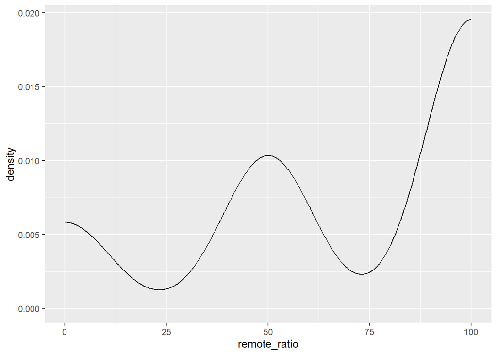

```r
df %>% ggplot()+
  geom_density(mapping = aes(x=remote_ratio))
```

# This graph shows what density of people work remotely.

- Histogram

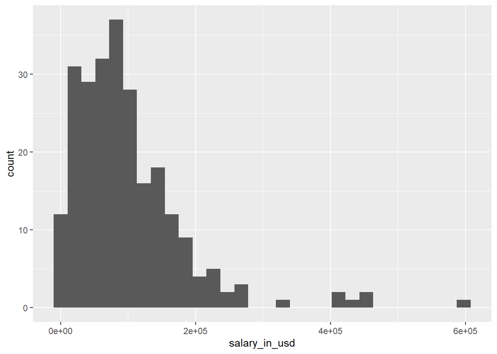

```r
df %>% ggplot()+
  geom_histogram(mapping = aes(x=salary_in_usd))
```

# This graph shows how many employees make certain amounts for salaries.

- Boxplot

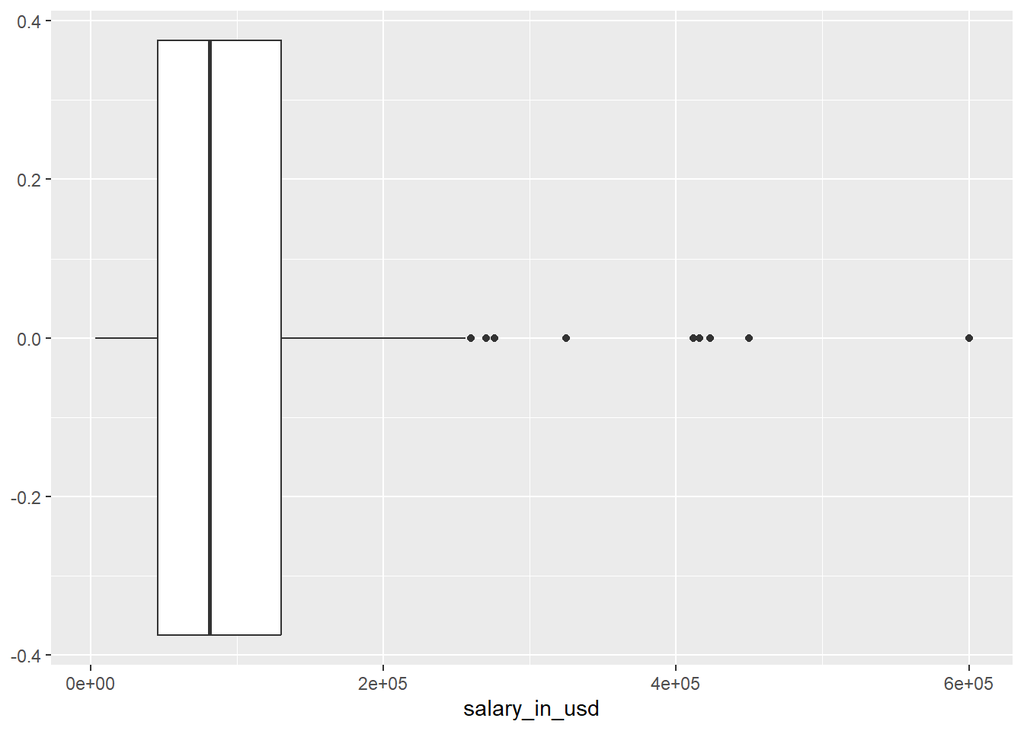

```r
df %>% ggplot()+
  geom_boxplot(mapping = aes(x=salary_in_usd))
```

# This graph shows how many employees make certain amounts for salaries, but in a box and points rather than columns. ——-

2. For one categorical variable
- Barplot

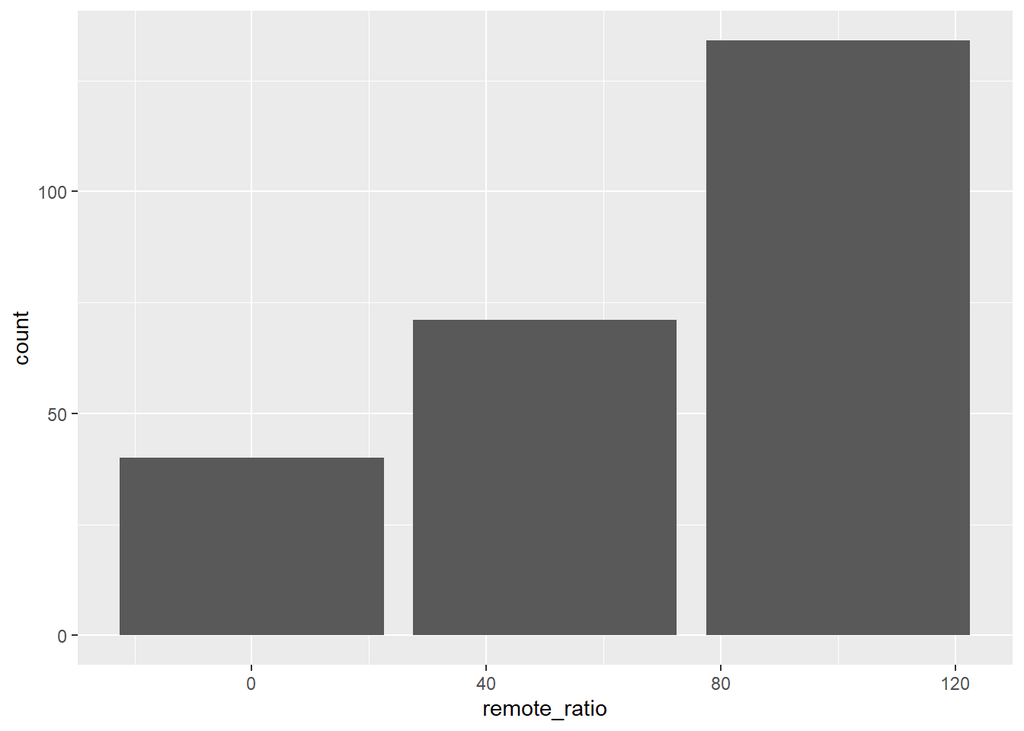

```r
df %>% ggplot()+
  geom_bar(mapping = aes(x=remote_ratio))
```

# These columns show the population of how many employees were remotely.

3. For two continuous variables
- Scatter Plot

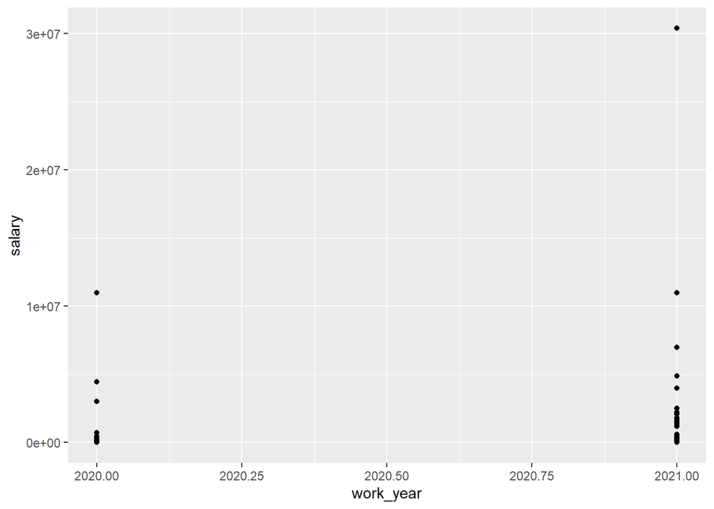

```r
df %>% ggplot()+geom_point(aes(x=work_year, y=salary))
```

# This shows dots for the differfence in salaries between work years.

- Line Plot

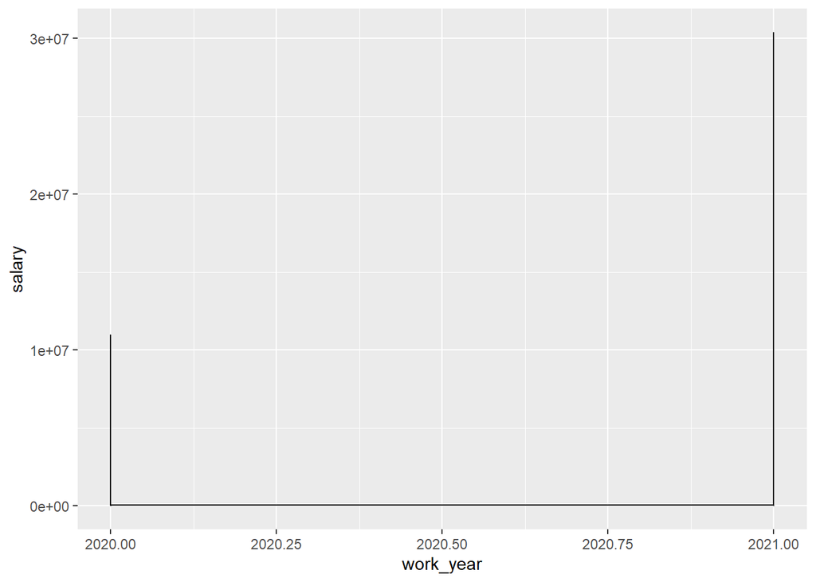

```r
df %>% ggplot()+geom_line(aes(x=work_year, y=salary))
```

# This shows lines for the differfence in salaries between work years.

- Smooth Plot

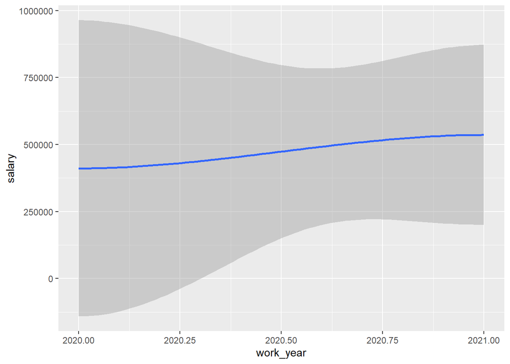

```r
df %>% ggplot()+geom_smooth(aes(x=work_year, y=salary))
```

# This shows a line with margins for the differfence in salaries between work years.

4. For one continuous + one categorical variables
- Density

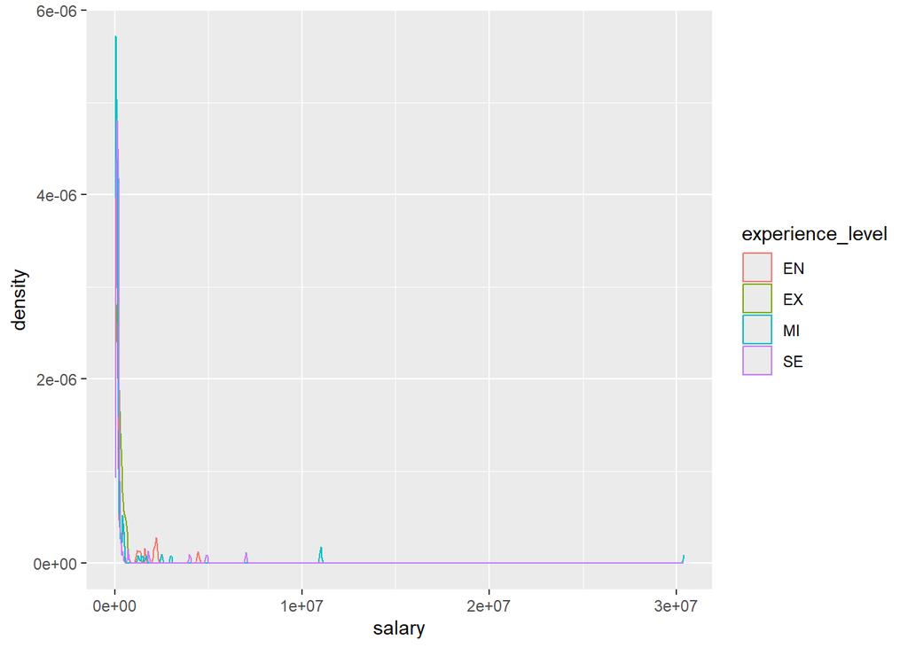

```r
df %>% ggplot()+
  geom_density(mapping = aes(x=salary , color=experience_level))
```

# This shows densities for how many people make certain salaries in density.

- BoxPlot

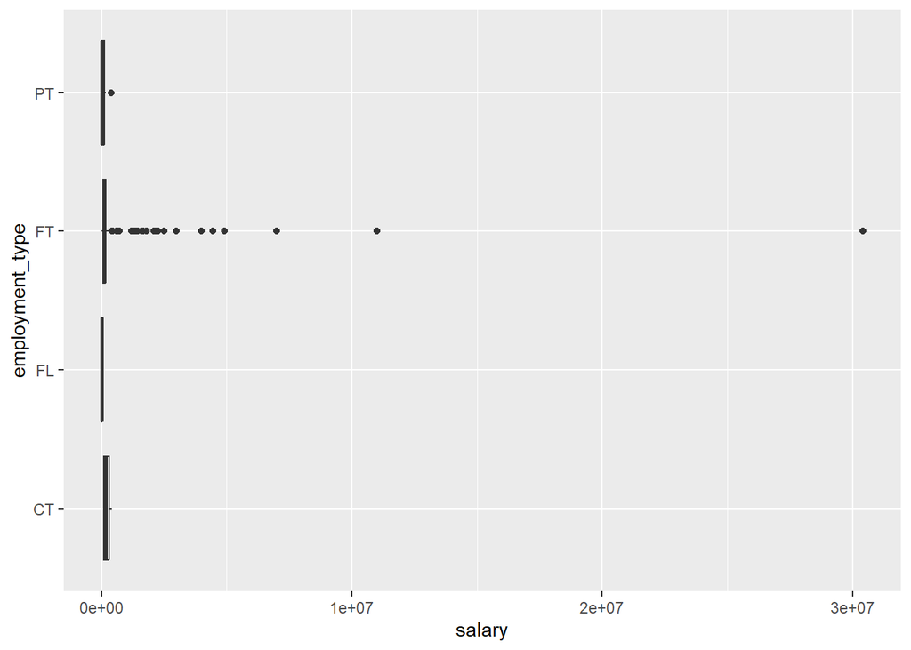

```r
df %>% ggplot()+
  geom_boxplot(mapping = aes(x=salary , y=employment_type))
```